# Dengue Fever Forecasting

Author

Shaun Harrington

**Data Exploration**

**Weekly Cases**

The original series is quite volatile and the exponential characteristics are plainly visible.

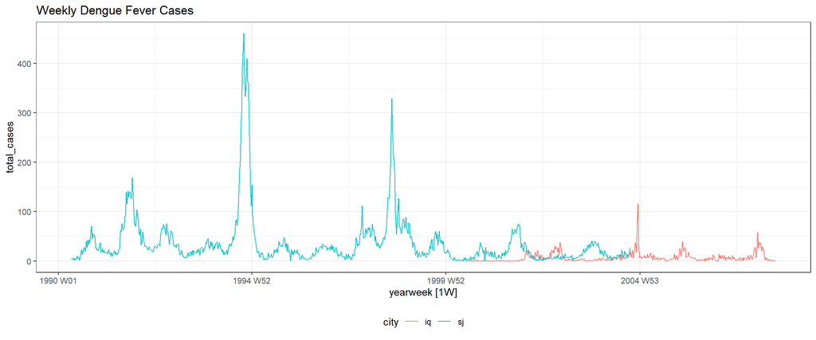

**Case Rate**

Using the case rate ($\frac{Total Cases}{Population}$) makes the two series comparable between cities but the exponential nature is still present.

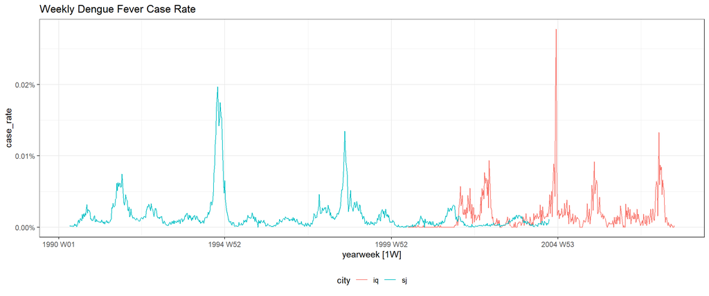

**Case Rate, Transformed**

A logit transformation aids considerably with the exponential nature of the series.

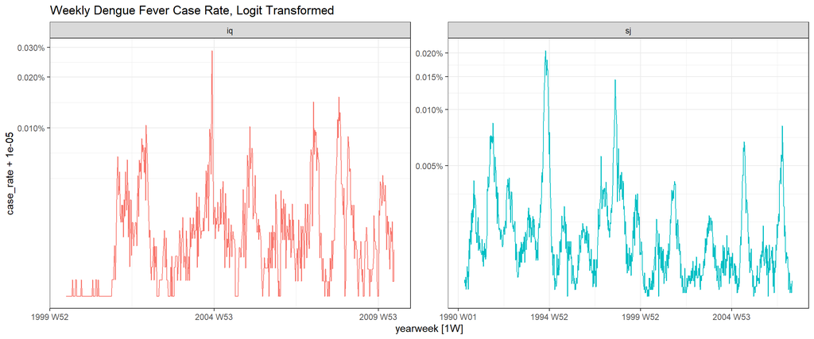

### Seasonality

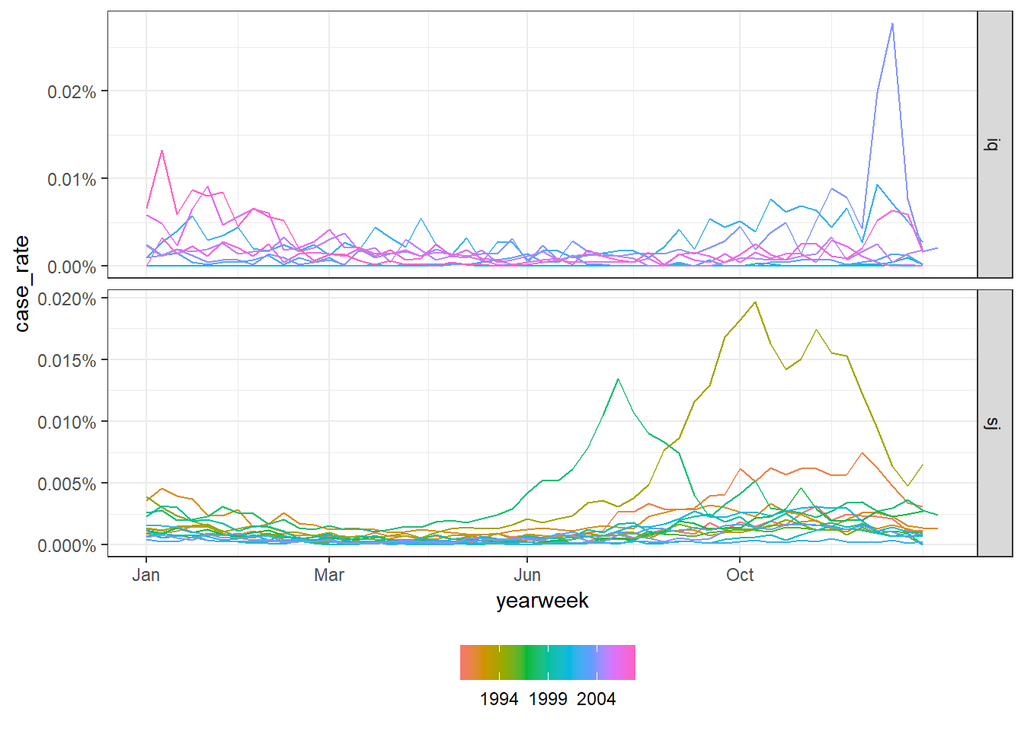

### Decomposition

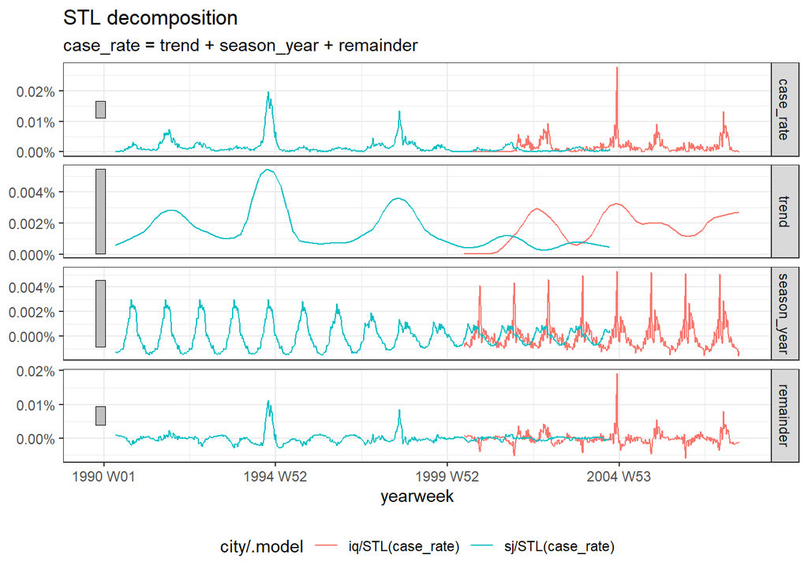

**Feature Engineering**

- Growing Degree Days: sum(max(Average temperature - baseline, 0))
- Rolling averages & sums: precipitation, GDD, humidity
- Seasonally adjusted values (STL decomposition)
- Principal components (little productivity though)

**Time Plots**

- Cases seem positively correlated with warmer, wetter years.

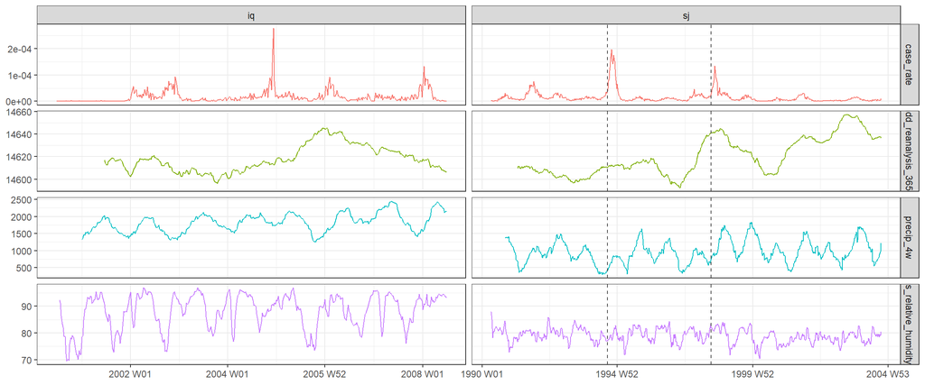

> hdd_reanalysis_365d: the rolling 365-day sum of Growing Degree Days.

> precip_4w: rolling 4-week sum of precipitation.

> reanalysis_relative_humidity_percent: rolling 4-week average humidity level.

**Complex nature**

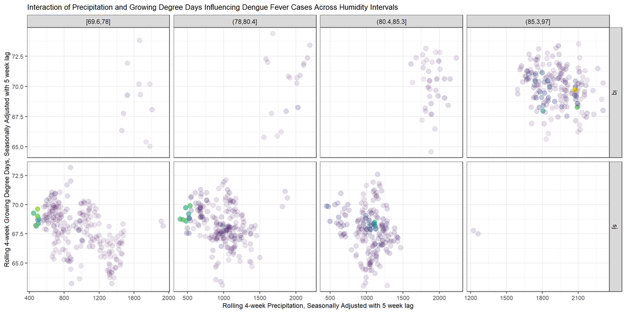

The yellow & green points represent weeks with high case counts cluster together within lags of GDD, precipitation, and humidity.

**Model Estimation**

**Model 1: Mean**

Simple approach that takes average seasonality from training set plus a trend.

Uses Box-Cox-transformed cumulative cases as dependent variable.

**Iquitos**

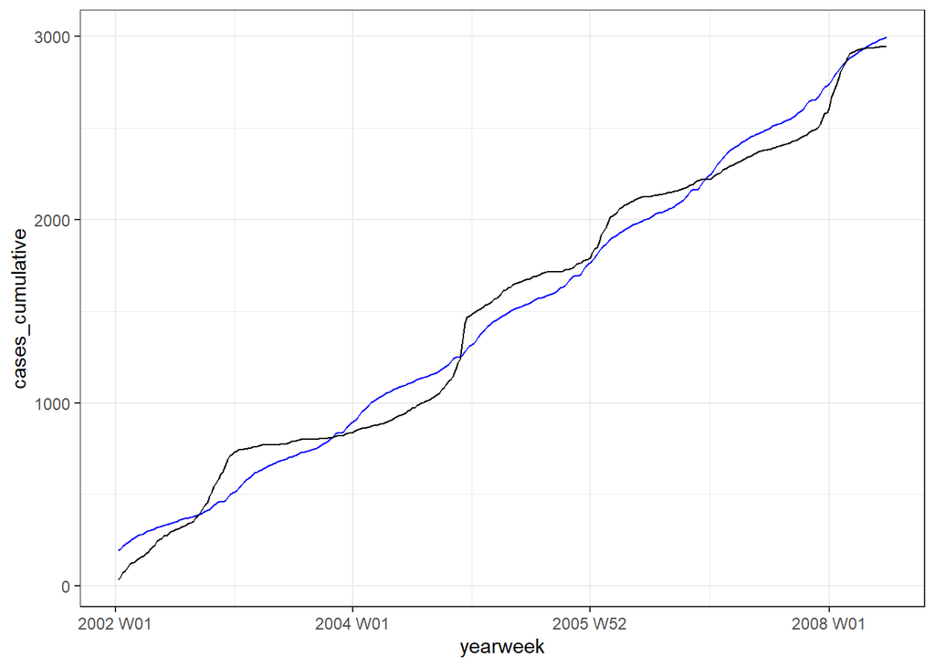

```
Series: cases_cumulative
Model: TSLM
Transformation: box_cox(cases_cumulative, 0.8)

Residuals:
     Min       1Q   Median       3Q      Max
-65.8251 -24.2638   0.7582  25.5745  60.8679

Coefficients:
                       Estimate Std. Error t value Pr(>|t|)
(Intercept)           69.259123   3.167770  21.864  < 2e-16 ***
fourier(K = 10)C1_52  -5.937540   2.223602  -2.670  0.00796 **
fourier(K = 10)S1_52   5.529331   2.247047   2.461  0.01439 *
fourier(K = 10)C2_52  -0.770517   2.237233  -0.344  0.73077
fourier(K = 10)S2_52  -0.432201   2.233603  -0.193  0.84669
fourier(K = 10)C3_52   0.461228   2.240770   0.206  0.83705
fourier(K = 10)S3_52  -0.728809   2.229282  -0.327  0.74394
fourier(K = 10)C4_52   0.346102   2.235770   0.155  0.87707
fourier(K = 10)S4_52  -0.520515   2.232862  -0.233  0.81582
fourier(K = 10)C5_52  -0.252953   2.233045  -0.113  0.90988
fourier(K = 10)S5_52  -0.103213   2.236094  -0.046  0.96321
fourier(K = 10)C6_52  -0.083698   2.236029  -0.037  0.97016
fourier(K = 10)S6_52  -0.284016   2.232653  -0.127  0.89885
fourier(K = 10)C7_52  -0.150296   2.238011  -0.067  0.94650
fourier(K = 10)S7_52  -0.435508   2.230284  -0.195  0.84530
fourier(K = 10)C8_52  -0.162870   2.235463  -0.073  0.94196
fourier(K = 10)S8_52  -0.370150   2.232891  -0.166  0.86844
fourier(K = 10)C9_52  -0.006666   2.233409  -0.003  0.99762
fourier(K = 10)S9_52  -0.539527   2.234041  -0.242  0.80932
fourier(K = 10)C10_52  0.057938   2.233319   0.026  0.97932
fourier(K = 10)S10_52 -0.523912   2.229565  -0.235  0.81437
trend()                1.990779   0.015917 125.074  < 2e-16 ***
---
Signif. codes:  0 '***' 0.001 '**' 0.01 '*' 0.05 '.' 0.1 ' ' 1

Residual standard error: 29.22 on 322 degrees of freedom
Multiple R-squared:  0.98,  Adjusted R-squared: 0.9787
F-statistic: 751.2 on 21 and 322 DF, p-value: < 2.22e-16
```

**San Juan**

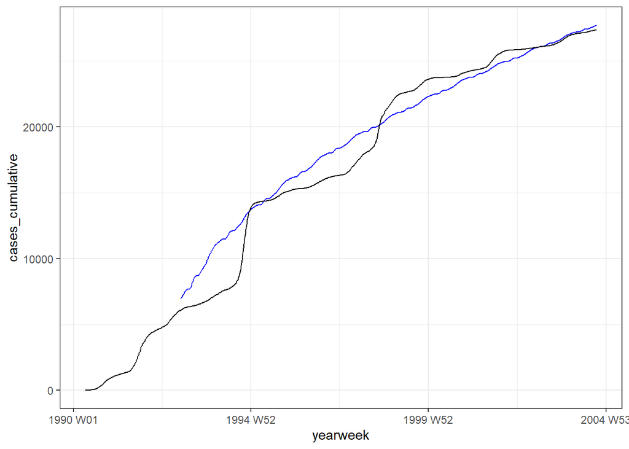

```
Series: cases_cumulative
Model: TSLM
Transformation: box_cox(cases_cumulative, 2.15)

Residuals:
       Min         1Q     Median         3Q        Max
-179785290  -81917267   -3092162   80182059  255963446

Coefficients:
                      Estimate Std. Error t value Pr(>|t|)
(Intercept)         -256867823    7692590 -33.392   <2e-16 ***
fourier(K = 5)C1_52    6606093    5437673   1.215    0.225
fourier(K = 5)S1_52    6284496    5431041   1.157    0.248
fourier(K = 5)C2_52    3322212    5424787   0.612    0.540
fourier(K = 5)S2_52    1718151    5444936   0.316    0.752
fourier(K = 5)C3_52   -1296480    5427427  -0.239    0.811
fourier(K = 5)S3_52    -601486    5440980  -0.111    0.912
fourier(K = 5)C4_52    1752075    5438125   0.322    0.747
fourier(K = 5)S4_52    -434368    5429958  -0.080    0.936
fourier(K = 5)C5_52   -1079323    5437257  -0.199    0.843
fourier(K = 5)S5_52     502796    5428475   0.093    0.926
trend()                2563225      17748 144.428   <2e-16 ***
---
Signif. codes:  0 '***' 0.001 '**' 0.01 '*' 0.05 '.' 0.1 ' ' 1

Residual standard error: 105200000 on 738 degrees of freedom
Multiple R-squared: 0.9659, Adjusted R-squared: 0.9653
F-statistic:  1898 on 11 and 738 DF, p-value: < 2.22e-16
```

**Model 2: ARIMAX**

- Autoregressive model with exogenous variables including fourier terms.
- Uses Box-Cox-transformed cumulative cases as dependent variable.

**Iquitos**

```
Series: cases_cumulative
Model: LM w/ ARIMA(1,1,0)(1,0,0)[52] errors
Transformation: box_cox(cases_cumulative, 0.7)

Coefficients:
         ar1     sar1  fourier(K = 5)C1_52  fourier(K = 5)S1_52
      0.6519  -0.0010              -2.7045               4.1080
s.e.  0.0427   0.0629               1.6721               1.6831
      fourier(K = 5)C2_52  fourier(K = 5)S2_52  fourier(K = 5)C3_52
                  -0.0695               0.8510              -0.0007
s.e.               0.7589               0.7576               0.4447
      fourier(K = 5)S3_52  fourier(K = 5)C4_52  fourier(K = 5)S4_52
                   0.2554              -0.0685               0.2284
s.e.               0.4476               0.2943               0.2930
      fourier(K = 5)C5_52  fourier(K = 5)S5_52  lag(precip_4w, n = 10)
                  -0.2536               0.1585                  -6e-04
s.e.               0.2073               0.2069                   1e-03
      lag(hdd_reanalysis_4w_sa * humidity_rel_avg_4w_sa, n = 6)
                                                              0
s.e.                                                          0
      lag(station_diur_temp_rng_c, n = 5)  lag(hdd_reanalysis_365d_sa, n = 5)
                                   0.0216                              0.0169
s.e.                               0.0223                              0.0031
      lag(hdd_station_365d, n = 10)  lag(precip_365d_sa, n = 8)  intercept
                            -0.0166                       7e-04     1.0447
s.e.                         0.0478                       1e-03     0.1005

sigma^2 estimated as 0.9097:  log likelihood=-451.07
AIC=942.14   AICc=944.75   BIC=1018.83
```

**San Juan**

```
Series: cases_cumulative
Model: LM w/ ARIMA(2,1,0) errors
Transformation: box_cox(cases_cumulative, 1.3)

Coefficients:
         ar1      ar2  fourier(K = 2)C1_52  fourier(K = 2)S1_52
      1.1405  -0.1884             2609.247             3103.219
s.e.  0.0384   0.0385             1062.156             1060.969
      fourier(K = 2)C2_52  fourier(K = 2)S2_52
                 325.9158             -50.9702
s.e.             288.0283             288.4371
      lag(rollmean(reanalysis_min_air_temp_k, k = 8, NA, align = "right"), n = 8)
                                                                           0.1215
s.e.                                                                      65.3842
      lag(hdd_reanalysis_4w, n = 9)  lag(reanalysis_tdtr_k_sa_smooth, n = 6)
                             3.0207                                 249.8516
s.e.                        10.7532                                 656.0112
      population  intercept
          0.1142   596.0623
s.e.      0.3360   203.6325

sigma^2 estimated as 54172:  log likelihood=-4533.52
AIC=9091.04   AICc=9091.48   BIC=9146.28
```

**Model 3: Prophet with Boosted Errors**

- Fits a Prophet model first, then the errors are modeled using boosted trees (xgboost algorithm).
- Prophet model aims to capture average seasonality and trend.
- xgboost model aims to model nonlinearity.
- Uses logit-transformed case rate as dependent variable.

**Iquitos**

[output not shown]

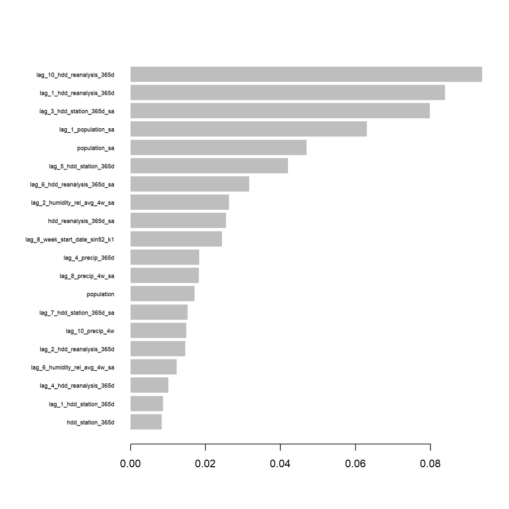

**San Juan**

[output not shown]

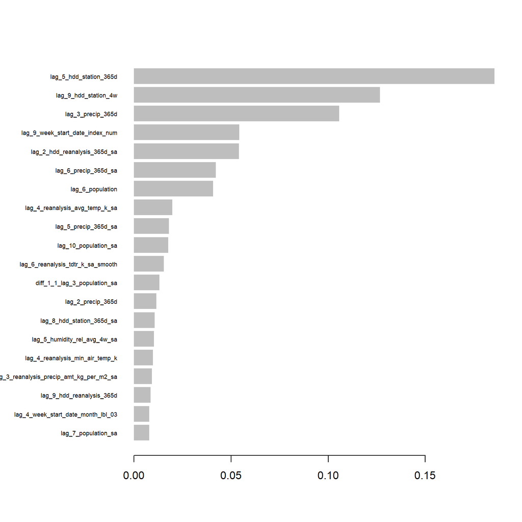

**Forecast**

**Validation Set**

- Iquitos models were trained on 2000-06-26 UTC–2008-06-23 UTC with the validation set covering 2008-06-30 UTC–2010-06-21 UTC.
- San Juan models were trained on 1990-04-30 UTC–2004-09-20 UTC with the validation set covering 2004-09-27 UTC–2008-04-21 UTC.

#### Iquitos

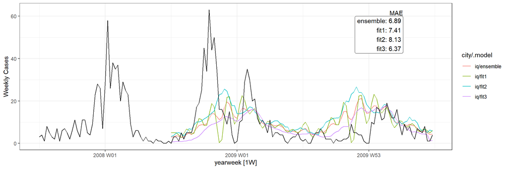

#### San Juan

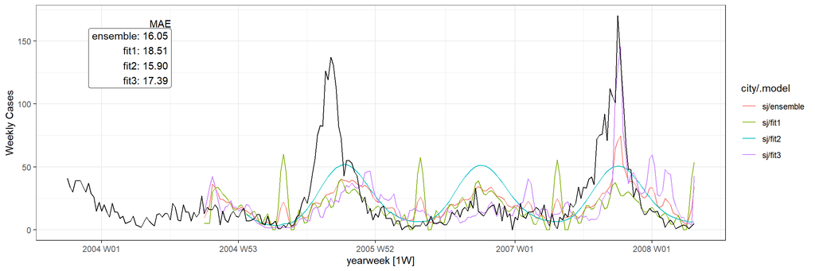

#### Mean Absolute Error

```
# A tibble: 4 × 4
  .model   model_description                 iq    sj
  <chr>    <chr>                          <dbl> <dbl>
1 ensemble Simple average of other models  6.89  16.0
2 fit1     Average seasonality plus trend  7.41  18.5
3 fit2     ARIMAX                          8.13  15.9
4 fit3     Prophet with Boosted Trees      6.37  17.4
```

> Iquitos has a lower mean absolute error than San Juan, however, this is likely a result of having an average of 7.54 weekly cases to San Juan’s average of 34.1 during the training set.

> The Prophet with Boosted Trees performs best for Iquitos.

**Test Set**

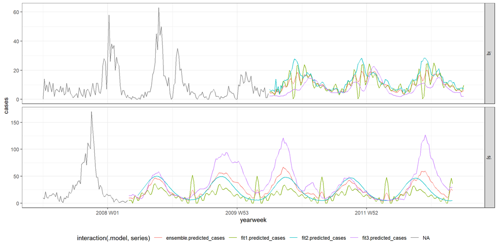

Data was split into a training set, validation set, and the test set.